```python
import numpy as np
import csv
from matplotlib import pylab as plt
import pandas as pd
```

```python
%cd /Users/yifan/Library/CloudStorage/Dropbox/Current Projects/2024-AlonLab-yeast/
```

```
[Errno 2] No such file or directory: '/Users/yifan/Library/CloudStorage/Dropbox/Current Projects/2024-AlonLab-yeast/'
/Users/yifan/Dropbox/Current Projects/2024-AlonLab-yeast
```

# Preparing the tools I will use for quality control

```python
from scipy.stats import ks_2samp, kstest, ksone
from scipy.special import binom

from scipy.cluster.hierarchy import average, complete, dendrogram, fcluster
```

```python
cleaner_df = pd.read_csv("McCormick yeastdata (for Glen)/cleaner_yeastdata (YPD,30C,20+).csv")
```

```python
def divisionsSplit(string):
    return [float(w) for w in string.split(',')]
```

```python
from scipy.optimize import newton
from scipy.stats import norm, chi2

def _criticalPartialBrownianBridge(alpha, maxcdf=0.999, alternative='two-sided'):

    R_MaxCDF = maxcdf
    R_func = np.sqrt(R_MaxCDF-R_MaxCDF*R_MaxCDF)

    if alternative=='two-sided':
        alpha = alpha/2

    return newton(lambda x:1-alpha-norm.cdf(x/R_func) + norm.cdf((2*R_MaxCDF-1)*x/R_func)*np.exp(-2*x*x), 1.5)
```

# Focusing on genes with both mating types?

```python
allGenes= np.unique(cleaner_df["set_genotype"])

counts = []
for gene in allGenes:
    counts.append((gene,
        len(cleaner_df.loc[np.array(cleaner_df["set_genotype"]== gene)]),
        len(cleaner_df.loc[np.array(cleaner_df["set_genotype"]== gene) & np.array(cleaner_df['set_background']== 'BY4742')]),
        len(cleaner_df.loc[np.array(cleaner_df["set_genotype"]== gene) & np.array(cleaner_df['set_background']== 'BY4741')])
          ))
countsDf = pd.DataFrame(columns=["gene","exp","matalpha","MATa"],data=counts)

coupleGenes = np.array(countsDf.loc[np.array(countsDf['MATa']>0)&np.array(countsDf['matalpha']>0),'gene'])
deepGenes = np.array(countsDf.loc[np.array(countsDf['MATa']==0)&np.array(countsDf['matalpha']>1),'gene'])
singleGenes = np.array(countsDf.loc[np.array(countsDf['MATa']==0)&np.array(countsDf['matalpha']==1),'gene'])
coupleDeepGenes = np.array(countsDf.loc[np.array(countsDf['MATa']>0)&np.array(countsDf['matalpha']>1),'gene'])
coupleShallowGenes = np.array(countsDf.loc[np.array(countsDf['MATa']>0)&np.array(countsDf['matalpha']==1),'gene'])

catCounts = [len(deepGenes), len(singleGenes),len(coupleGenes), len(coupleDeepGenes),len(coupleShallowGenes)]
catLabels = ["more than 1 MATalpha experiment but no MATa",
             "only 1 MATalpha expierment and no MAT a",
             "both mating types",
             "both mating types and more than 1 MATalpha",
             "both mating types and only 1 MATalpha"
            ]
[ print(str(x)+" genes with "+str(y)) for (x,y) in zip(catCounts, catLabels)];
```

```
181 genes with more than 1 MATalpha experiment but no MATa
606 genes with only 1 MATalpha expierment and no MAT a
754 genes with both mating types
393 genes with both mating types and more than 1 MATalpha
361 genes with both mating types and only 1 MATalpha
```

# For now let's just focus on los1

```python
gene = 'los1'
background = 'BY4742'
ids = np.array(cleaner_df.loc[np.array(cleaner_df["set_genotype"]== gene) & np.array(cleaner_df['set_background']== background) ].index)
```

## Let's use KS distance between the control survival curves from each experiment to cluster them

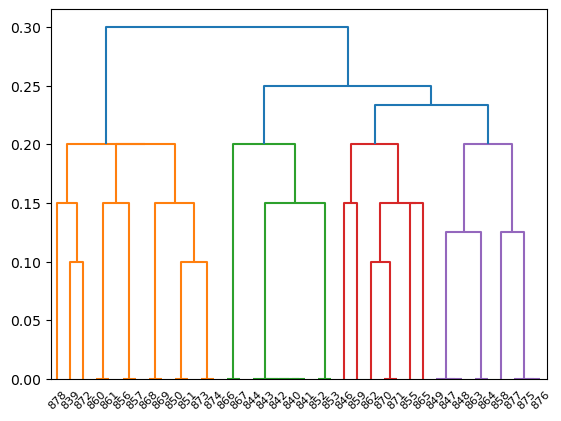

```python
distances = np.zeros((len(ids),len(ids)))
significances = np.empty((len(ids),len(ids)))
pdist = np.zeros(int(binom(len(ids), 2)))
significances[:] = np.NAN
significances_pd = np.zeros(int(binom(len(ids), 2)))
k = 0
for i in range(len(ids)):
    for j in range(i+1,len(ids)):
        test = ks_2samp(divisionsSplit(cleaner_df.loc[ids[i], 'ref_lifespans'])/cleaner_df.loc[ids[i], 'ref_lifespan_mean'],
                        divisionsSplit(cleaner_df.loc[ids[j], 'ref_lifespans'])/cleaner_df.loc[ids[j], 'ref_lifespan_mean'] )
        distances[i][j] = test[0]
        distances[j][i] = test[0]
        if type(test[1]) is str:
            significances[i][j] = 0
        elif test[1] > 0.05:
            significances[i][j] = 0
        elif test[1] > 0.02:
            significances[i][j] = 1
        else:
            significances[i][j] = 2
        significances[j][i] = significances[i][j]
        pdist[k] = distances[i][j]
        significances_pd = significances[i][j]
        k+=1

alpha=0.1
#cutoff = ksone.ppf(1-alpha/len(ids)/(len(ids)-1)*2, 20)
#cutoff = ksone.ppf(1-alpha/52, 20)
cutoff = ksone.ppf(1-alpha, 20)
dn = dendrogram(complete(pdist),labels=ids, color_threshold=cutoff )
```

##### However, to properly identify signifant differences when many control cohorts are compared with pair-wise test, we need to apply False-Disocvery Discovery

### Here we use the Benjamini-Hochberg method, and estimate the cutoff to be alpha/Ninsig, where Ninsig are the number of insignificant test

##### This is a interative method, but we skip that by setting Ninsig conservatively to be number of insignificant pair-wise comparisions when the cutoff is not adjusted higher at all

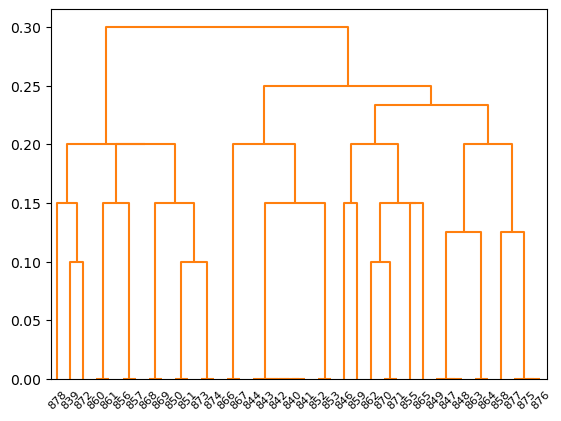

```python
distances = np.zeros((len(ids),len(ids)))
significances = np.empty((len(ids),len(ids)))
pdist = np.zeros(int(binom(len(ids), 2)))
significances[:] = np.NAN
significances_pd = np.zeros(int(binom(len(ids), 2)))
k = 0
for i in range(len(ids)):
    for j in range(i+1,len(ids)):
        test = ks_2samp(divisionsSplit(cleaner_df.loc[ids[i], 'ref_lifespans'])/cleaner_df.loc[ids[i], 'ref_lifespan_mean'],
                        divisionsSplit(cleaner_df.loc[ids[j], 'ref_lifespans'])/cleaner_df.loc[ids[j], 'ref_lifespan_mean'] )
        distances[i][j] = test[0]
        distances[j][i] = test[0]
        if type(test[1]) is str:
            significances[i][j] = 0
        elif test[1] > 0.05:
            significances[i][j] = 0
        elif test[1] > 0.02:
            significances[i][j] = 1
        else:
            significances[i][j] = 2
        significances[j][i] = significances[i][j]
        pdist[k] = distances[i][j]
        significances_pd = significances[i][j]
        k+=1

alpha=0.1
#cutoff = ksone.ppf(1-alpha/len(ids)/(len(ids)-1)*2, 20)
cutoff = ksone.ppf(1-alpha/52, 20)
#cutoff = ksone.ppf(1-alpha, 20)
dn = dendrogram(complete(pdist),labels=ids, color_threshold=cutoff )
```

### Even with this conservative cutoff, the control experiments now have no significant differences

### Now we apply a similar process to all los1 cohorts

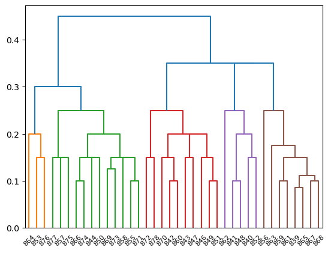

```python
distances = np.zeros((len(ids),len(ids)))
significances = np.empty((len(ids),len(ids)))
pdist = np.zeros(int(binom(len(ids), 2)))
significances[:] = np.NAN
significances_pd = np.zeros(int(binom(len(ids), 2)))
k = 0
for i in range(len(ids)):
    for j in range(i+1,len(ids)):
        test = ks_2samp(divisionsSplit(cleaner_df.loc[ids[i], 'set_lifespans'])/cleaner_df.loc[ids[i], 'set_lifespan_mean'],
                        divisionsSplit(cleaner_df.loc[ids[j], 'set_lifespans'])/cleaner_df.loc[ids[j], 'set_lifespan_mean'] )
        distances[i][j] = test[0]
        distances[j][i] = test[0]
        if type(test[1]) is str:
            significances[i][j] = 0
        elif test[1] > 0.05:
            significances[i][j] = 0
        elif test[1] > 0.02:
            significances[i][j] = 1
        else:
            significances[i][j] = 2
        significances[j][i] = significances[i][j]
        pdist[k] = distances[i][j]
        significances_pd = significances[i][j]
        k+=1

alpha=0.05
#cutoff = ksone.ppf(1-alpha/len(ids)/(len(ids)-1)*2, 20)
cutoff = ksone.ppf(1-alpha, 20)
dn = dendrogram(complete(pdist),labels=ids, color_threshold=cutoff )
```

##### los1 cohorts have no repeats

### Applying Benjameni-Hochberg correction conservatively

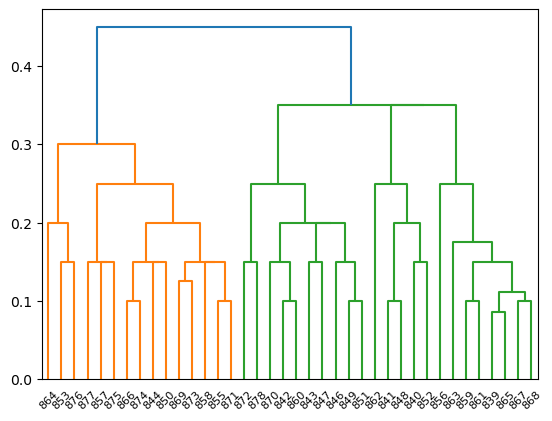

```python
distances = np.zeros((len(ids),len(ids)))
significances = np.empty((len(ids),len(ids)))
pdist = np.zeros(int(binom(len(ids), 2)))
significances[:] = np.NAN
significances_pd = np.zeros(int(binom(len(ids), 2)))
k = 0
for i in range(len(ids)):
    for j in range(i+1,len(ids)):
        test = ks_2samp(divisionsSplit(cleaner_df.loc[ids[i], 'set_lifespans'])/cleaner_df.loc[ids[i], 'set_lifespan_mean'],
                        divisionsSplit(cleaner_df.loc[ids[j], 'set_lifespans'])/cleaner_df.loc[ids[j], 'set_lifespan_mean'] )
        distances[i][j] = test[0]
        distances[j][i] = test[0]
        if type(test[1]) is str:
            significances[i][j] = 0
        elif test[1] > 0.05:
            significances[i][j] = 0
        elif test[1] > 0.02:
            significances[i][j] = 1
        else:
            significances[i][j] = 2
        significances[j][i] = significances[i][j]
        pdist[k] = distances[i][j]
        significances_pd = significances[i][j]
        k+=1

alpha=0.1
#cutoff = ksone.ppf(1-alpha/len(ids)/(len(ids)-1)*2, 20)
cutoff = ksone.ppf(1-alpha/152, 20)
dn = dendrogram(complete(pdist),labels=ids, color_threshold=cutoff )
```

##### Iterate once, the result converged

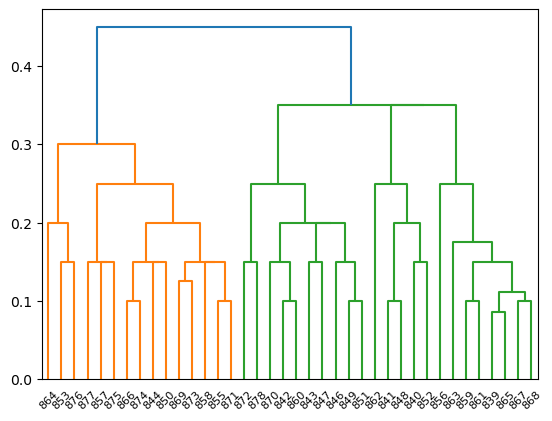

```python
distances = np.zeros((len(ids),len(ids)))
significances = np.empty((len(ids),len(ids)))
pdist = np.zeros(int(binom(len(ids), 2)))
significances[:] = np.NAN
significances_pd = np.zeros(int(binom(len(ids), 2)))
k = 0
for i in range(len(ids)):
    for j in range(i+1,len(ids)):
        test = ks_2samp(divisionsSplit(cleaner_df.loc[ids[i], 'set_lifespans'])/cleaner_df.loc[ids[i], 'set_lifespan_mean'],
                        divisionsSplit(cleaner_df.loc[ids[j], 'set_lifespans'])/cleaner_df.loc[ids[j], 'set_lifespan_mean'] )
        distances[i][j] = test[0]
        distances[j][i] = test[0]
        if type(test[1]) is str:
            significances[i][j] = 0
        elif test[1] > 0.05:
            significances[i][j] = 0
        elif test[1] > 0.02:
            significances[i][j] = 1
        else:
            significances[i][j] = 2
        significances[j][i] = significances[i][j]
        pdist[k] = distances[i][j]
        significances_pd = significances[i][j]
        k+=1

alpha=0.1
#cutoff = ksone.ppf(1-alpha/len(ids)/(len(ids)-1)*2, 20)
cutoff = ksone.ppf(1-alpha/358, 20)
dn = dendrogram(complete(pdist),labels=ids, color_threshold=cutoff )
```

### Conclusion here is that there is some detectable day-to-day and experiment-to-experiment variability, more so in a mutant than wildtype. But overall the experiment is very well run with very limited day-to-day variability

# Now we use the mean lifespan to get a sense of whether strictly pairing control and treated experiments can reduce day-to-day and experiment-to-experiment variability

```python
import seaborn as sns
import statsmodels.api as sm
from lifelines import KaplanMeierFitter

gene_df = cleaner_df.loc[np.array(cleaner_df["set_genotype"]== 'los1')]
```

## Day-to-day variability should cause the control and mutant experiments to be correlated

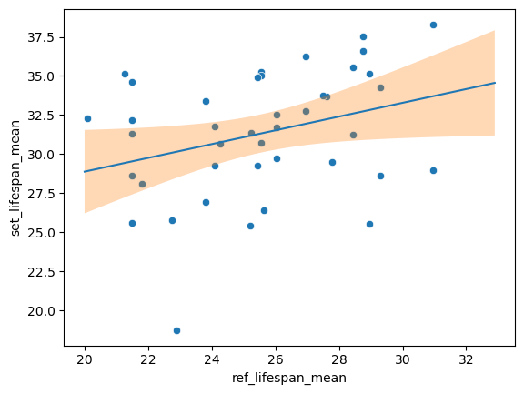

```python
sns.scatterplot(data=gene_df,
               x="ref_lifespan_mean",y="set_lifespan_mean")

X = sm.add_constant(gene_df["ref_lifespan_mean"])
ols_model = sm.OLS(gene_df["set_lifespan_mean"], X)
est = ols_model.fit()
out = est.conf_int(alpha=0.05, cols=None)

Xrange = np.arange(20, 33 ,0.1)
y_pred = est.predict([(1,x) for x in Xrange])
x_pred = gene_df["ref_lifespan_mean"]
pred = est.get_prediction([(1,x) for x in Xrange]).summary_frame()

plt.fill_between(Xrange, pred['mean_ci_upper'], pred['mean_ci_lower'], alpha=0.3)
plt.plot(Xrange, y_pred, color=sns.color_palette()[0])


#plt.errorbar("ref_lifespan_mean",
#             "set_lifespan_mean",
#             yerr="set_lifespan_stdev",
#             xerr="ref_lifespan_stdev",
#            fmt=".",data=gene_df)
```

```python
est.summary()
```

OLS Regression Results

| Dep. Variable: | set_lifespan_mean | R-squared: | 0.100 |
| --- | --- | --- | --- |
| Model: | OLS | Adj. R-squared: | 0.077 |
| Method: | Least Squares | F-statistic: | 4.353 |
| Date: | Mon, 27 Jan 2025 | Prob (F-statistic): | 0.0435 |
| Time: | 15:30:13 | Log-Likelihood: | -112.60 |
| No. Observations: | 41 | AIC: | 229.2 |
| Df Residuals: | 39 | BIC: | 232.6 |
| Df Model: | 1 |  |  |
| Covariance Type: | nonrobust |  |  |

|  | coef | std err | t | P>\|t\| | [0.025 | 0.975] |
| --- | --- | --- | --- | --- | --- | --- |
| const | 20.0825 | 5.423 | 3.703 | 0.001 | 9.113 | 31.052 |
| ref_lifespan_mean | 0.4400 | 0.211 | 2.086 | 0.044 | 0.013 | 0.867 |

| Omnibus: | 5.031 | Durbin-Watson: | 2.059 |
| --- | --- | --- | --- |
| Prob(Omnibus): | 0.081 | Jarque-Bera (JB): | 3.996 |
| Skew: | -0.749 | Prob(JB): | 0.136 |
| Kurtosis: | 3.307 | Cond. No. | 231. |

Notes:  
[1] Standard Errors assume that the covariance matrix of the errors is correctly specified.

## If we broaden this analysis to all genes, not just los1

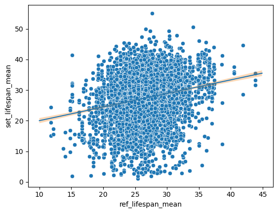

```python
sns.scatterplot(data=cleaner_df,
               x="ref_lifespan_mean",y="set_lifespan_mean")

X = sm.add_constant(cleaner_df["ref_lifespan_mean"])
ols_model = sm.OLS(cleaner_df["set_lifespan_mean"], X)
est = ols_model.fit()
out = est.conf_int(alpha=0.05, cols=None)

Xrange = np.arange(10, 45 ,0.1)
y_pred = est.predict([(1,x) for x in Xrange])
x_pred = cleaner_df["ref_lifespan_mean"]
pred = est.get_prediction([(1,x) for x in Xrange]).summary_frame()

plt.fill_between(Xrange, pred['mean_ci_upper'], pred['mean_ci_lower'], alpha=0.3)
plt.plot(Xrange, y_pred, color=sns.color_palette()[0])
```

```python
est.summary()
```

OLS Regression Results

| Dep. Variable: | set_lifespan_mean | R-squared: | 0.047 |
| --- | --- | --- | --- |
| Model: | OLS | Adj. R-squared: | 0.046 |
| Method: | Least Squares | F-statistic: | 310.9 |
| Date: | Mon, 27 Jan 2025 | Prob (F-statistic): | 5.53e-68 |
| Time: | 15:34:34 | Log-Likelihood: | -21598. |
| No. Observations: | 6364 | AIC: | 4.320e+04 |
| Df Residuals: | 6362 | BIC: | 4.321e+04 |
| Df Model: | 1 |  |  |
| Covariance Type: | nonrobust |  |  |

|  | coef | std err | t | P>\|t\| | [0.025 | 0.975] |
| --- | --- | --- | --- | --- | --- | --- |
| const | 15.5794 | 0.675 | 23.085 | 0.000 | 14.256 | 16.902 |
| ref_lifespan_mean | 0.4437 | 0.025 | 17.634 | 0.000 | 0.394 | 0.493 |

| Omnibus: | 386.573 | Durbin-Watson: | 0.912 |
| --- | --- | --- | --- |
| Prob(Omnibus): | 0.000 | Jarque-Bera (JB): | 501.047 |
| Skew: | -0.572 | Prob(JB): | 1.58e-109 |
| Kurtosis: | 3.763 | Cond. No. | 201. |

Notes:  
[1] Standard Errors assume that the covariance matrix of the errors is correctly specified.

# Lastly, we want to see whether experiment-to-exerpiment variability is limited to mean lifespan, i.e. whether temporal scaling can eliminate experiment-to-exerpiment differences

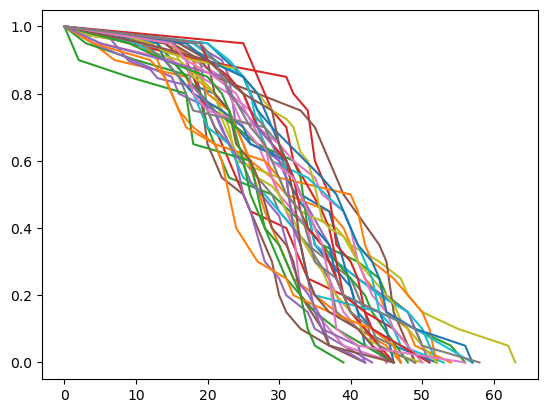

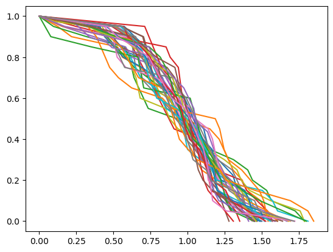

```python
for i, id in enumerate(ids):
    kmf = KaplanMeierFitter()
    kmf.fit([int(t) for t in gene_df.loc[id,'set_lifespans'].split(',')],
            [True for t in gene_df.loc[id,'set_lifespans'].split(',')]
           )

    plt.plot(kmf.timeline, kmf.survival_function_, label=id)

plt.figure()
for i, id in enumerate(ids):
    kmf = KaplanMeierFitter()
    kmf.fit([float(t)/gene_df.loc[id,'set_lifespan_mean'] for t in gene_df.loc[id,'set_lifespans'].split(',')],
            [True for t in gene_df.loc[id,'set_lifespans'].split(',')]
           )
    plt.plot(kmf.timeline, kmf.survival_function_, label=id)
```

```python
(np.std([gene_df.loc[id,'ref_lifespan_mean'] for id in ids ]), np.mean([gene_df.loc[id,'ref_lifespan_stdev'] for id in ids ]))
```

```
(2.7792140802283676, 9.14015792105263)
```

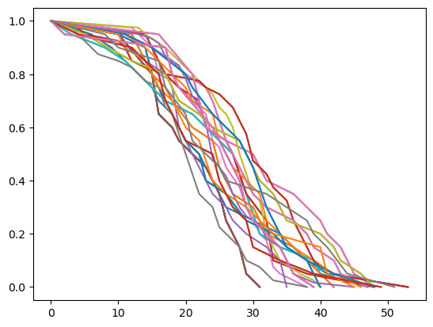

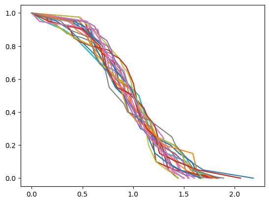

```python
for i, id in enumerate(ids):
    kmf = KaplanMeierFitter()
    kmf.fit([int(t) for t in gene_df.loc[id,'ref_lifespans'].split(',')],
            [True for t in gene_df.loc[id,'ref_lifespans'].split(',')]
           )

    plt.plot(kmf.timeline, kmf.survival_function_, label=id)

plt.figure()
for i, id in enumerate(ids):
    kmf = KaplanMeierFitter()
    kmf.fit([float(t)/gene_df.loc[id,'ref_lifespan_mean'] for t in gene_df.loc[id,'ref_lifespans'].split(',')],
            [True for t in gene_df.loc[id,'ref_lifespans'].split(',')]
           )
    plt.plot(kmf.timeline, kmf.survival_function_, label=id)
```